# Clasificación

Barrera Borla, Gonzalo y Duarte, Octavio M.

27 de Noviembre

```r
library('tidyverse')
library('randomForest')
library('caret')
library('knitr')
knitr::opts_chunk$set(echo=F, cache=F, warning = F, message = F, fig.align = 'left' )
```

### Epílogo

*Ignorante que blasonas de sabio: angustiado te veo entre el infinito del pasado y el infinito del porvenir. Quisieras poner límite entre estos dos infinitos y detenerte… Siéntate antes bajo un árbol con un cántaro de vino y olvidarás tu impotencia.*

Omar Jayam, Rubaiyat.

# Exploración

Parece natural introducir una transformada del tiempo de ciclo de procesador que sea la inversa, “freq”. Sobre todo porque la relación de “más es mejor” es más intuitiva.

## Gráfico de Facetas

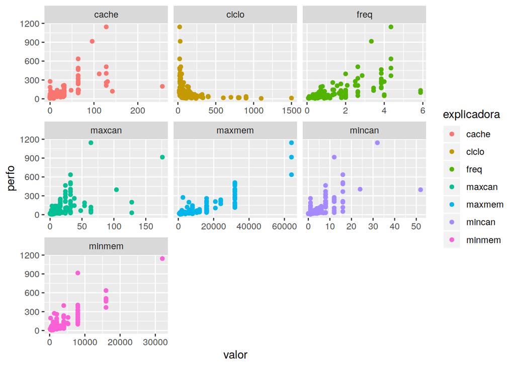

En este gráfico anticipamos algunos patrones que pueden parecer preocupantes. La forma cónica en que se disponen los puntos parece indicar que si se adaptara un modelo lineal (al menos uno monovariado respecto a cualquiera de ellas) este sería heteroscedástico. Es muy probable que alguna transformada de la variable `perfo` nos de un mejor rendimiento.

## Correlaciones

|  | ciclo | minmem | maxmem | cache | mincan | maxcan | perfo | freq |
| --- | --- | --- | --- | --- | --- | --- | --- | --- |
| ciclo | 1.0000000 | -0.3273828 | -0.3835603 | -0.3092915 | -0.3073165 | -0.2500881 | -0.3049861 | -0.5592968 |
| minmem | -0.3273828 | 1.0000000 | 0.7850211 | 0.4981817 | 0.5912883 | 0.2761253 | 0.8561144 | 0.6784717 |
| maxmem | -0.3835603 | 0.7850211 | 1.0000000 | 0.5112143 | 0.5691799 | 0.4445348 | 0.8745141 | 0.6555079 |
| cache | -0.3092915 | 0.4981817 | 0.5112143 | 1.0000000 | 0.6243662 | 0.5466662 | 0.6540835 | 0.4364231 |
| mincan | -0.3073165 | 0.5912883 | 0.5691799 | 0.6243662 | 1.0000000 | 0.5602787 | 0.6729118 | 0.5067791 |
| maxcan | -0.2500881 | 0.2761253 | 0.4445348 | 0.5466662 | 0.5602787 | 1.0000000 | 0.5433722 | 0.2058922 |
| perfo | -0.3049861 | 0.8561144 | 0.8745141 | 0.6540835 | 0.6729118 | 0.5433722 | 1.0000000 | 0.6064111 |
| freq | -0.5592968 | 0.6784717 | 0.6555079 | 0.4364231 | 0.5067791 | 0.2058922 | 0.6064111 | 1.0000000 |

- La mejor correlación con la variable en estudio la presentan las variables asociadas a la memoria `minmem` con 0.8561144 y `maxmem` 0.8745141.
- La correlación entre ellas mismas es alta 0.7850211.
- Excepto `ciclo` todas las demás tienen una correlación suficiente como para suponer que se puede extraer información útil al modelo de ellas. La transformada de `ciclo`, `freq` sí muestra una correlación razonable.

# Intento de Transformar la variable Objetivo

Vemos si disminuyen estos patrones gráficos preocupantes.

## Transformando la Repuesta

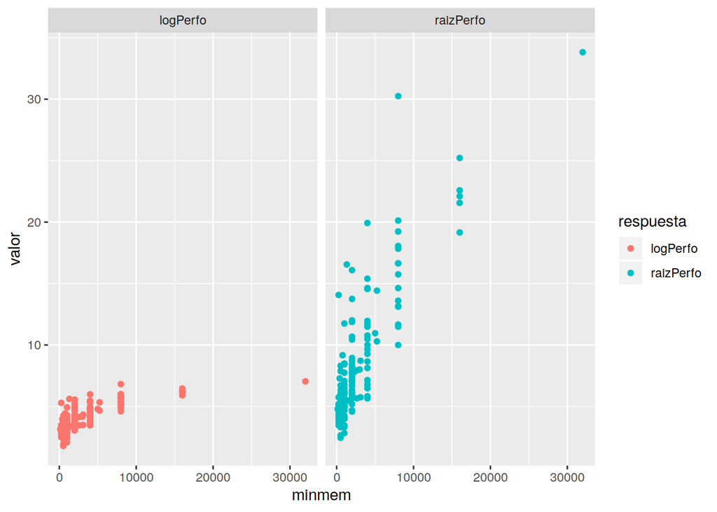

# Elección de un Método

Armados de estas nociones para orientarnos, recurrimos a iterar una lista muy grande de modelos sobre los métodos que conocemos. Dadas las particulares circunstancias de una competencia, decidimos priorizar la precisión de las predicciones sobre otras cualidades usualmente deseables como la interpretabilidad.

Un paquete que homogeneiza esta la tarea de entrenar modelos para una gran cantidad de algoritmos es `caret`. Este separa la tarea de realizar una predicción en varias etapas, todas modulares y por lo tanto fue posible programar la métrica particular que estamos usando en esta trabajo, *alfa podada* al 80%. Además, se definió esta medición de tal forma que acepta una función inversa. De esta manera, pudimos realizar regresiones sobre modelos donde la variable está transformada (dado que las observaciones preliminares parecieron revelar la ventaja de estas transformaciones, $y_1=\log{y}$ e $y_2=\sqrt{y}$) pero medir el *Error Medio Cuadrático Alfa Podado* sobre nuestra variable respuesta original. Una primera observación es que esta poda homogeneiza drásticamente el rendimiento de los modelos y por lo tanto fue una batalla cabeza a cabeza, al menos entre los modelos que nosotros conocemos.

# Modelo Seleccionado

## Diagrama QQ

Comparamos las performances relativas ajustadas y las observadas.

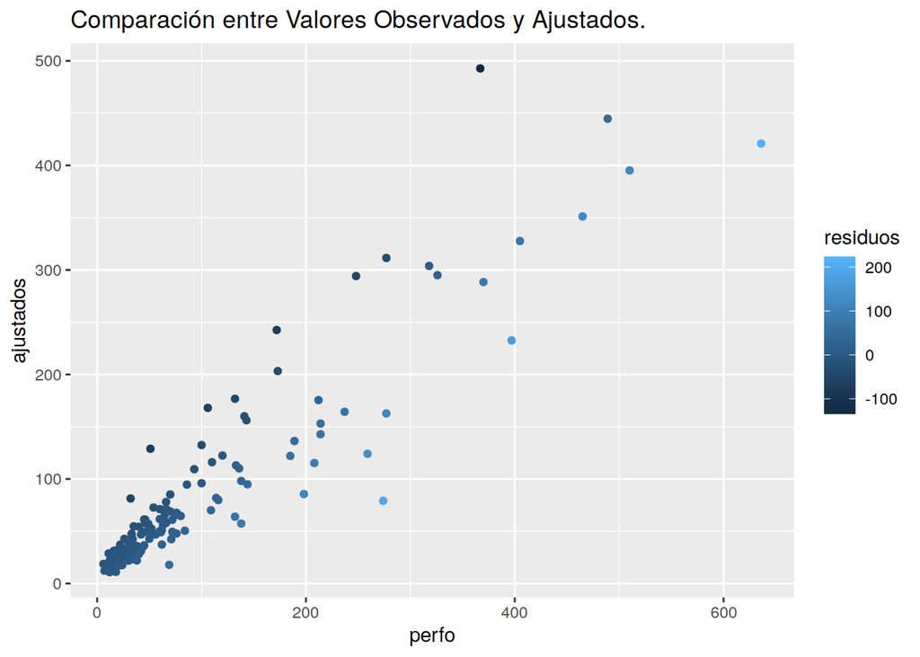

En línea con la métrica propuesta para esta competencia, repetimos el mismo gráfico con los datos de mayor residuo eliminados.

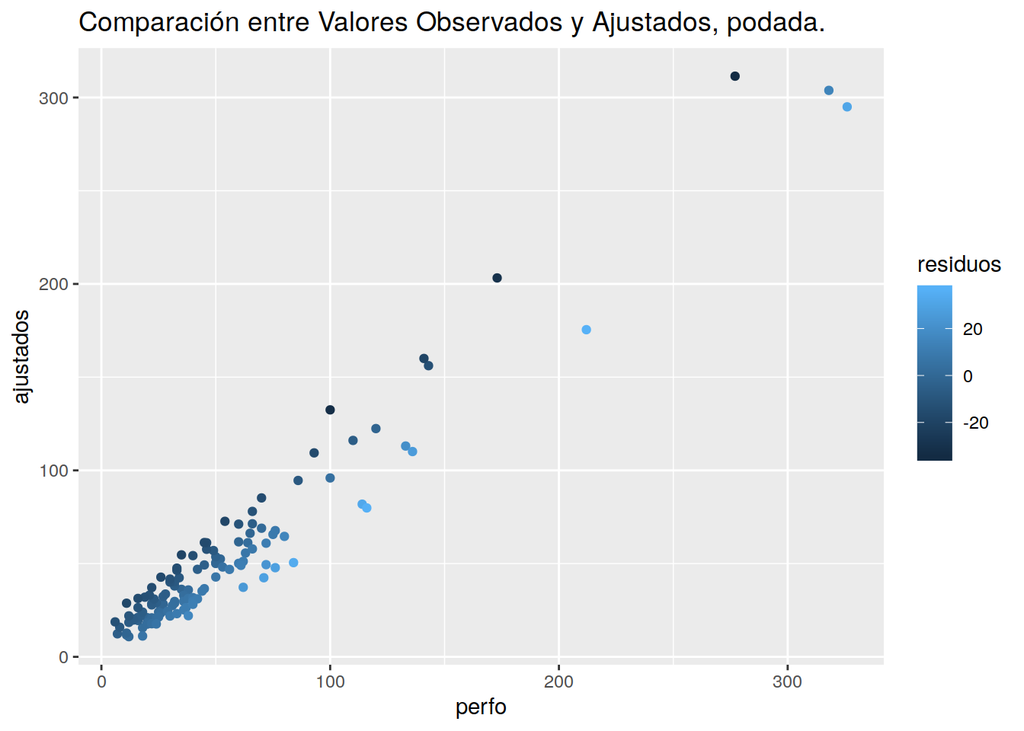

## Residuos contra Perfo

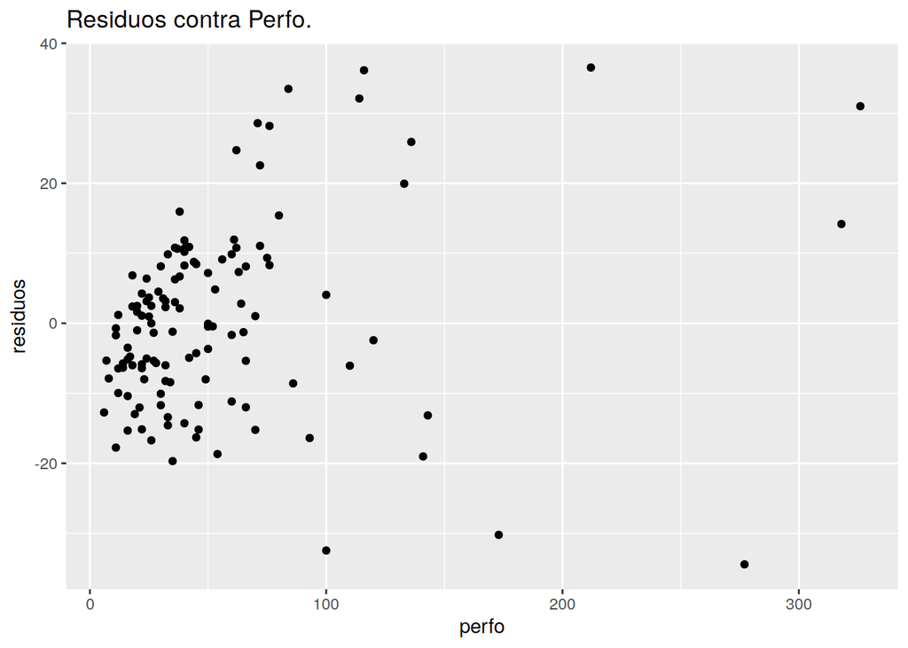